# Assemble and explore patient cohort

## Load Data

We’ll start by looking at all cases on file, including fresh frozen (FF) and FFPE samples, those that are laser capture microdissected (LCM) and those that are not, and assessing their cellularity. Samples where tumor content is above 30% are kept. We also keep only one tumor specimen per patient.

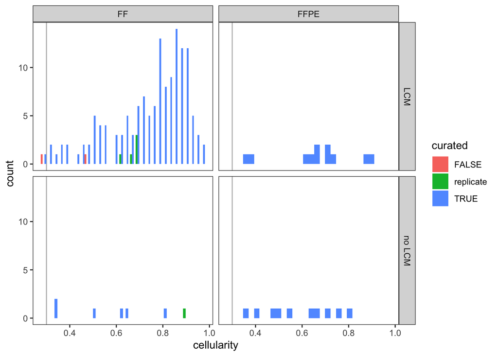

```r
suppressPackageStartupMessages({
  library(data.table)
  library(ggplot2)
  library(tidyverse)
  library(dplyr)
  library(mclust)
  library(multimode)
  library(diptest)
  library(ggsankey)
  library(ggh4x)
  library(PNWColors)
  library(cowplot)
  library(table1)
  library(survival)
  library(survminer)
  library(ggfortify)
  library(gtsummary)
  library(ggforce)
  library(tidyr)
  library(readxl)
  library(ggupset)
})

`%ni%` <- Negate(`%in%`)

make_clean_names <- function(all.clinic){
  clean_names <- iconv(names(all.clinic), from = "", to = "UTF-8", sub = "")
  spaced_names <- gsub(" ", "_", clean_names)

  alpha_names <- gsub("[^A-Za-z0-9_]", "", spaced_names)
  names(all.clinic) <- alpha_names
  names(all.clinic) <- make.unique(names(all.clinic), sep = "_")
  return(all.clinic)
}

align_df2_to_df1 <- function(df1, df2) {
  # Get the column names from df1
  target_cols <- names(df1)

  # Create missing columns in df2 with NA
  for (col in setdiff(target_cols, names(df2))) {
    df2[[col]] <- NA
  }

  # Drop extra columns and reorder to match df1
  df2_aligned <- df2[, target_cols, drop = FALSE]

  combined <- rbind(df1, df2_aligned)
  return(combined)
}

fix_excel_dates <- function(df) {
  df_fixed <- df

  for (col_name in names(df_fixed)) {
    col <- df_fixed[[col_name]]

    # Check if column is character and all non-NA values are numeric strings
    if (is.character(col)) {
      non_na_values <- col[!is.na(col)]

      if (all(grepl("^\\d+$", non_na_values))) {
        col_numeric <- as.numeric(col)

        df_fixed[[col_name]] <- as.Date(col_numeric, origin = "1899-12-30")

      } else {
        df_fixed[[col_name]] <- as.Date(col)
      }
    }
  }

  return(df_fixed)
}

basedir = '~/Documents/scripts/github/btc-ccs/'
secdir = '~/Documents/scripts/github/evolution/'

excel_path = file.path(secdir,"/source_data/LegresleyBiliaryRegi_DATA_LABELS_2025-12-04_1305.xlsx")

BTC_clinical.tumours <- fread(file.path(basedir,'/source_data/BTC_clinical.tumours.tsv'), header=T)
btc.cellularity <- fread(file.path(basedir,'/results/btc.cellularity.curated.txt'), col.names = c('Sample','cellularity','ploidy'), header=F)
BTC_clinical.tumours <- full_join(BTC_clinical.tumours, btc.cellularity)
sample.list <- fread(file.path(basedir,'/source_data/sample.list.txt'), col.names = c('donor','tumour','normal'), header=F)

BTC_clinical.tumours$curated <- F
BTC_clinical.tumours$curated[BTC_clinical.tumours$Sample %in% sample.list$tumour] <- T

replicates <- BTC_clinical.tumours %>% group_by(Donor) %>% tally() %>% filter(n>1)
BTC_clinical.tumours$replicates <- F
BTC_clinical.tumours$replicates[BTC_clinical.tumours$Donor %in% replicates$Donor] <- T

BTC_clinical.tumours$curated[BTC_clinical.tumours$curated == F & BTC_clinical.tumours$replicates == T] <- 'replicate'

ggplot(BTC_clinical.tumours, aes(x=cellularity, fill=curated)) +
  geom_vline(xintercept = 0.3, color='grey')+
  facet_grid(`Group ID(LCM/non-LCM)` ~ `Sample Source(FFPE, FF)`)+
  geom_histogram(position=position_dodge()) +
  theme_bw() +
  theme(panel.grid = element_blank())
```

```r
BTC_clinical.tumours <- BTC_clinical.tumours %>% filter(curated == T)

rna.tpm.all <- fread(file.path(secdir,"/results/rna.tpm.all.txt"))

BTC_clinical.tumours$rna <- F
BTC_clinical.tumours$rna[BTC_clinical.tumours$Sample %in% names(rna.tpm.all)] <- T

BTC_clinical.tumours$previous <- 'new'
BTC_clinical.tumours$previous <- ifelse(substr(BTC_clinical.tumours$Sample, 5, 5) == "9", 'Holzapfel 2023', BTC_clinical.tumours$previous)

mtb.cohort <- fread(file.path(basedir,'/source_data/cohort_outcomes.txt'))
BTC_clinical.tumours$previous[BTC_clinical.tumours$Donor %in% mtb.cohort$BTC_ID] <- 'Beaudry 2025'

BTC_clinical.tumours %>% group_by(rna,`Sample Source(FFPE, FF)`,`Group ID(LCM/non-LCM)`,previous) %>% tally()
```

```
## # A tibble: 11 × 5
## # Groups:   rna, Sample Source(FFPE, FF), Group ID(LCM/non-LCM) [7]
##    rna   `Sample Source(FFPE, FF)` `Group ID(LCM/non-LCM)` previous           n
##    <lgl> <chr>                     <chr>                   <chr>          <int>
##  1 FALSE FF                        LCM                     Beaudry 2025       4
##  2 FALSE FF                        LCM                     Holzapfel 2023    19
##  3 FALSE FF                        LCM                     new                6
##  4 FALSE FF                        no LCM                  new                3
##  5 FALSE FFPE                      LCM                     new                3
##  6 TRUE  FF                        LCM                     Beaudry 2025      47
##  7 TRUE  FF                        LCM                     new               66
##  8 TRUE  FF                        no LCM                  new                3
##  9 TRUE  FFPE                      LCM                     new                8
## 10 TRUE  FFPE                      no LCM                  Beaudry 2025       2
## 11 TRUE  FFPE                      no LCM                  new                8
```

```r
BTC_clinical.tumours %>% group_by(previous) %>% tally()
```

```
## # A tibble: 3 × 2
##   previous           n
##   <chr>          <int>
## 1 Beaudry 2025      53
## 2 Holzapfel 2023    19
## 3 new               97
```

```r
specimen_type_n <- BTC_clinical.tumours %>% group_by(`Sample Source(FFPE, FF)`,`Group ID(LCM/non-LCM)`,rna) %>% tally()
sum(specimen_type_n$n)
```

```
## [1] 169
```

```r
BTC_clinical.tumours %>% group_by(`Group ID(LCM/non-LCM)`) %>% tally()
```

```
## # A tibble: 2 × 2
##   `Group ID(LCM/non-LCM)`     n
##   <chr>                   <int>
## 1 LCM                       153
## 2 no LCM                     16
```

```r
BTC_clinical.tumours %>% group_by(`Sample Source(FFPE, FF)`) %>% tally()
```

```
## # A tibble: 2 × 2
##   `Sample Source(FFPE, FF)`     n
##   <chr>                     <int>
## 1 FF                          148
## 2 FFPE                         21
```

```r
BTC_clinical.tumours %>% group_by(rna) %>% tally()
```

```
## # A tibble: 2 × 2
##   rna       n
##   <lgl> <int>
## 1 FALSE    35
## 2 TRUE    134
```

```r
BTC_clinical.tumours %>% group_by(rna,`Sample Source(FFPE, FF)`) %>% tally()
```

```
## # A tibble: 4 × 3
## # Groups:   rna [2]
##   rna   `Sample Source(FFPE, FF)`     n
##   <lgl> <chr>                     <int>
## 1 FALSE FF                           32
## 2 FALSE FFPE                          3
## 3 TRUE  FF                          116
## 4 TRUE  FFPE                         18
```

```r
BTC_clinical.tumours %>% group_by(`Sample Source(FFPE, FF)`,`Group ID(LCM/non-LCM)`,rna) %>% tally()
```

```
## # A tibble: 7 × 4
## # Groups:   Sample Source(FFPE, FF), Group ID(LCM/non-LCM) [4]
##   `Sample Source(FFPE, FF)` `Group ID(LCM/non-LCM)` rna       n
##   <chr>                     <chr>                   <lgl> <int>
## 1 FF                        LCM                     FALSE    29
## 2 FF                        LCM                     TRUE    113
## 3 FF                        no LCM                  FALSE     3
## 4 FF                        no LCM                  TRUE      3
## 5 FFPE                      LCM                     FALSE     3
## 6 FFPE                      LCM                     TRUE      8
## 7 FFPE                      no LCM                  TRUE     10
```

```r
# Create a data framn# Create a data frame with a list-column
df <- data.frame(
  id = 1:7,
  stringsAsFactors = FALSE
)

df$sets <- list(
  c("FF", "LCM"),
  c("FF", "LCM", "RNA"),
  c("FF"),
  c("FF", "RNA"),
  c("LCM"),
  c("LCM", "RNA"),
  c("RNA")
)


df$n <- c(
  specimen_type_n$n[specimen_type_n$`Sample Source(FFPE, FF)` == 'FF' & specimen_type_n$`Group ID(LCM/non-LCM)` == 'LCM' &  specimen_type_n$rna == F],
  specimen_type_n$n[specimen_type_n$`Sample Source(FFPE, FF)` == 'FF' & specimen_type_n$`Group ID(LCM/non-LCM)` == 'LCM' &  specimen_type_n$rna == T],
  specimen_type_n$n[specimen_type_n$`Sample Source(FFPE, FF)` == 'FF' & specimen_type_n$`Group ID(LCM/non-LCM)` == 'no LCM' &  specimen_type_n$rna == F],
  specimen_type_n$n[specimen_type_n$`Sample Source(FFPE, FF)` == 'FF' & specimen_type_n$`Group ID(LCM/non-LCM)` == 'no LCM' &  specimen_type_n$rna == T],
  specimen_type_n$n[specimen_type_n$`Sample Source(FFPE, FF)` == 'FFPE' & specimen_type_n$`Group ID(LCM/non-LCM)` == 'LCM' &  specimen_type_n$rna == F],
  specimen_type_n$n[specimen_type_n$`Sample Source(FFPE, FF)` == 'FFPE' & specimen_type_n$`Group ID(LCM/non-LCM)` == 'LCM' &  specimen_type_n$rna == T],
  specimen_type_n$n[specimen_type_n$`Sample Source(FFPE, FF)` == 'FFPE' & specimen_type_n$`Group ID(LCM/non-LCM)` == 'no LCM' &  specimen_type_n$rna == T]
)

df <- df[order(df$n),]
sum(df$n)
```

```
## [1] 169
```

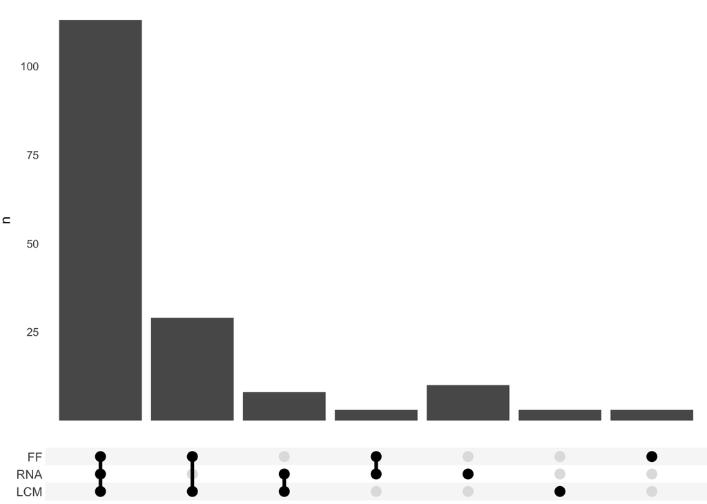

```r
specimen_type.tally <-  ggplot(df, aes(x = sets, y=n)) +

    geom_bar(stat='identity') +
    scale_x_upset(order_by = "degree",reverse = T) +
    theme_minimal(base_size=10) +
    #labs(y=('CMS-B LOD')) +
    theme(panel.grid = element_blank(),
          panel.background = element_blank(),
          plot.background = element_blank(),
          plot.margin = unit(c(0, 0, 0, 0), "mm"),
          axis.title.x = element_blank()) +
    scale_y_continuous(breaks = c(25,50,75, 100))

specimen_type.tally
```

```r
ggsave(paste0( basedir,"/results/fig/FIGS1B.specimen_type.tally.svg"),plot =specimen_type.tally
, device = "svg", width = 42, height = 50, units = 'mm', dpi=72 )

btc.coverage <- fread(file.path(basedir,'/results/btc.coverage.txt'))

median(btc.coverage$V4[btc.coverage$V1 %in% sample.list$tumour])
```

```
## [1] 85
```

```r
median(btc.coverage$V4[btc.coverage$V1 %in% sample.list$normal])
```

```
## [1] 38
```

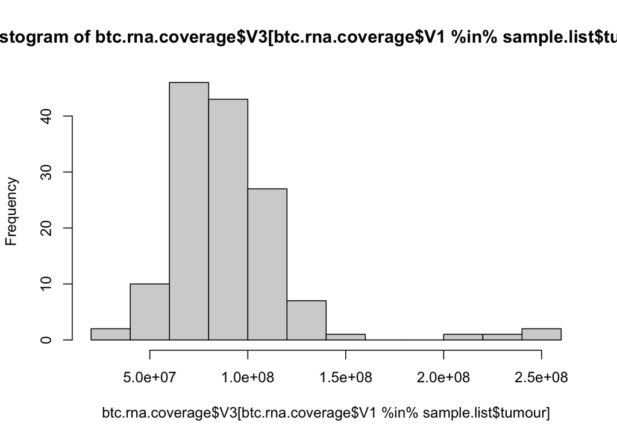

```r
btc.rna.coverage <- fread(file.path(basedir,'/results/btc.rna.coverage.txt'))

hist(btc.rna.coverage$V3[btc.rna.coverage$V1 %in% sample.list$tumour])
```

```r
cat(round(median(btc.rna.coverage$V3[btc.rna.coverage$V1 %in% sample.list$tumour])/1000000, 2), 'million transcripts')
```

```
## 84.21 million transcripts
```

## Add in clinical information

We first combine data from the LeGresley Biliary Registry with other BTC cases at UHN that have much less clinical annotation, mostly from the previous publication [Holzapfel et al 2023](https://dx.doi.org/10.21037/jgo-22-676). We do a little data cleaning and check broad cohort stats.

```r
suppressMessages({
suppressWarnings({
lbr.clinic.all <- read_excel(excel_path, sheet = 2, skip = 0)
})
})

lbr.clinic.all <- make_clean_names(lbr.clinic.all)
lbr.clinic.all$Study_ID <- sprintf("LBR-%04d", lbr.clinic.all$Study_ID)

lbr.clinic <- lbr.clinic.all %>% filter(is.na(Repeat_Instrument))
nrow(lbr.clinic)
```

```
## [1] 177
```

```r
BTC_clinical.tumours$EHR <- F
BTC_clinical.tumours$EHR[BTC_clinical.tumours$`Study ID` %in% lbr.clinic$Study_ID] <- T

suppressMessages({
suppressWarnings({
non.lbr.clinic <- read_excel(file.path(secdir,"/source_data/non-lbr.xlsx"), sheet = 1, skip = 0)
})
})

non.lbr.clinic <- make_clean_names(non.lbr.clinic)
BTC_clinical.tumours$EHR[BTC_clinical.tumours$Donor %in% non.lbr.clinic$BTC_ID] <- T
BTC_clinical.tumours %>% dplyr::select(`Study ID`, Donor, EHR) %>% arrange(desc(`Study ID`)) %>% filter(EHR == T) %>% nrow()
```

```
## [1] 169
```

```r
write.cohort.status = F
if(write.cohort.status){

write.table( BTC_clinical.tumours %>% dplyr::select(`Study ID`, Donor, EHR) %>% arrange(desc(`Study ID`)),
             file = file.path(basedir,"/results/cohort.wgts.txt"), row.names = FALSE, quote = FALSE, sep = "\t")

}

## match non-LBR names
names(non.lbr.clinic)[names(non.lbr.clinic) == "Age_at_Diagnosis"] <- 'Age_at_first_histological_diagnosis'
names(non.lbr.clinic)[names(non.lbr.clinic) == "Adjuvant_Chemotherapy_1"] <- 'Adjuvant_Chemotherapy'
names(non.lbr.clinic)[names(non.lbr.clinic) == "Sex"] <- 'Sex_assigned_at_birth'
names(non.lbr.clinic)[names(non.lbr.clinic) == "alive_holzapfel"] <- 'Status'

non.lbr.clinic$Status[non.lbr.clinic$Status == "F"] <- "Expired"
non.lbr.clinic$Status[non.lbr.clinic$Status == "T"] <- "Alive"

non.lbr.clinic$Sex_assigned_at_birth[non.lbr.clinic$Sex_assigned_at_birth == "Female (assumed or known XX)"] <- "Female"
non.lbr.clinic$Sex_assigned_at_birth[non.lbr.clinic$Sex_assigned_at_birth == "Male (assumed or known XY)"] <- "Male"

non.lbr.clinic$Anatomical_Location_choiceGallbladder <- "Unchecked"
non.lbr.clinic$Anatomical_Location_choiceGallbladder[non.lbr.clinic$anatomical_location == "GBC"] <- "Checked"

non.lbr.clinic$Anatomical_Location_choiceIntrahepatic_CCA_iCCA <- "Unchecked"
non.lbr.clinic$Anatomical_Location_choiceIntrahepatic_CCA_iCCA[non.lbr.clinic$anatomical_location == "iCCA"] <- "Checked"

non.lbr.clinic$Anatomical_Location_choiceExtrahepatic_CCA_eCCA <- "Unchecked"
non.lbr.clinic$Anatomical_Location_choiceExtrahepatic_CCA_eCCA[non.lbr.clinic$anatomical_location == "pCCA"] <- "Checked"
non.lbr.clinic$Specify_Extrahepatic_CCA_choicePerihilarHilar_Klatskins_pCCA <- "Unchecked"
non.lbr.clinic$Specify_Extrahepatic_CCA_choicePerihilarHilar_Klatskins_pCCA[non.lbr.clinic$anatomical_location == "pCCA"] <- "Checked"

non.lbr.clinic$Study_ID <- non.lbr.clinic$BTC_ID

non.lbr.clinic$Type_of_Surgery <- NA
non.lbr.clinic$Type_of_Surgery[non.lbr.clinic$Curative_surgery_attempted == 'Yes'] <- "Initial Curative"

non.lbr.clinic$First_line_palliative_chemotherapy_given_choiceGemcitabine <- NA
non.lbr.clinic$First_line_palliative_chemotherapy_given_choiceGemcitabine[!is.na(non.lbr.clinic$First_line_palliative_chemotherapy_given)] <- 'Checked'

all.clinic <- align_df2_to_df1(df1=lbr.clinic, df2=non.lbr.clinic)

all.clinic <- all.clinic %>% filter(Study_ID %in% BTC_clinical.tumours$`Study ID` | Study_ID %in% BTC_clinical.tumours$Donor )
nrow(all.clinic)
```

```
## [1] 169
```

```r
all.clinic$BMI[all.clinic$BMI > 10000 | all.clinic$BMI < 1] <- NA

median(round(all.clinic$Age_at_first_histological_diagnosis), na.rm = T)
```

```
## [1] 60
```

```r
min(round(all.clinic$Age_at_first_histological_diagnosis), na.rm = T)
```

```
## [1] 29
```

```r
max(round(all.clinic$Age_at_first_histological_diagnosis), na.rm = T)
```

```
## [1] 83
```

```r
table(is.na(all.clinic$Age_at_first_histological_diagnosis))
```

```
##
## FALSE  TRUE
##   167     2
```

```r
all.clinic$Sex_assigned_at_birth[is.na(all.clinic$Sex_assigned_at_birth) & !is.na(all.clinic$Sex8)] <- all.clinic$Sex8[is.na(all.clinic$Sex_assigned_at_birth) & !is.na(all.clinic$Sex8)]

table(all.clinic$Sex_assigned_at_birth)
```

```
##
## Female   Male
##     71     96
```

```r
inc.clinic <- all.clinic %>% filter(is.na(Sex_assigned_at_birth))
```

## Check Treatment Histories

This is almost entirely data cleaning, moving columns around so that first and second line treatments can be analyzed together, as well as normalizing drug names for uncommon drugs (that weren’t in the study schema).

```r
First_line_palliative_given <- all.clinic %>%
  dplyr::select(starts_with("Study_ID") |
                starts_with("First_line_palliative_chemotherapy_given") |
                starts_with("Specify_other_first_line_palliative_chemotherapy_or_clinical_trial") |
                starts_with("First_line_immunotherapy_given")) %>%
  reshape2::melt(id.vars = c('Study_ID')) %>%
  filter(value %ni% c('Unchecked','') & !is.na(value) &
          variable %ni% c('First_line_palliative_chemotherapy_given_choiceOther') )
First_line_palliative_given$variable <- gsub('First_line_palliative_chemotherapy_given_choice','',First_line_palliative_given$variable)
First_line_palliative_given$variable <- gsub('First_line_immunotherapy_given_choice','',First_line_palliative_given$variable)

First_line_palliative_given$variable[First_line_palliative_given$variable == 'Specify_other_first_line_palliative_chemotherapy_or_clinical_trial1621'] <-
    First_line_palliative_given$value[First_line_palliative_given$variable == 'Specify_other_first_line_palliative_chemotherapy_or_clinical_trial1621']

First_line_palliative_given <- First_line_palliative_given %>%
  group_by(Study_ID) %>%
  summarise(first_palliative = str_c(variable, collapse = "+"), .groups = "drop")

Second_line_palliative_given <- all.clinic %>%
  dplyr::select(
    starts_with("Study_ID") |
                  starts_with("Second_line_palliative_therapy_given") |
                  starts_with("Specify_other_second_line_palliative_therapy_or_clinical_trial") |
                  starts_with("Second_line_immunotherapy_given") |
                   starts_with("Other_second_line_immunotherapy")
      ) %>%
  reshape2::melt(id.vars = c('Study_ID')) %>%
  filter(value %ni% c('Unchecked','') & !is.na(value) &
           variable %ni% c('Second_line_palliative_therapy_given_choiceOther', 'Second_line_immunotherapy_given_choiceOther') )

Second_line_palliative_given$variable <- gsub('Second_line_palliative_therapy_given_choice','',Second_line_palliative_given$variable)
Second_line_palliative_given$variable <- gsub('Second_line_immunotherapy_given_choice','',Second_line_palliative_given$variable)

Second_line_palliative_given$variable[Second_line_palliative_given$variable == 'Specify_other_second_line_palliative_therapy_or_clinical_trial'] <-
  Second_line_palliative_given$value[Second_line_palliative_given$variable == 'Specify_other_second_line_palliative_therapy_or_clinical_trial']

Second_line_palliative_given$variable[Second_line_palliative_given$variable == 'Other_second_line_immunotherapy'] <-
  Second_line_palliative_given$value[Second_line_palliative_given$variable == 'Other_second_line_immunotherapy']

Second_line_palliative_given <- Second_line_palliative_given %>%
  group_by(Study_ID) %>%
  summarise(second_palliative = str_c(variable, collapse = "+"), .groups = "drop")

palliative <- full_join(First_line_palliative_given, Second_line_palliative_given)
palliative[palliative == "Cisplatingemcitabine+Durvalumab"] <- 'GemCis + Durva'
palliative[palliative == "Cisplatingemcitabine"] <- 'GemCis'

palliative[palliative == "gemcitabine carboplatin and durvalumab+Durvalumab"] <- 'GemCarbo + Durva'
palliative[palliative == "carboplatin/gemcitabine+Durvalumab"] <- 'GemCarbo + Durva'

palliative[palliative == "Trial+Ivosidenib (ProvIDHe)"] <- "Ivosidenib"
palliative[palliative == "Trial+ivosidenib"] <- "Ivosidenib"
palliative[palliative == "Trial+Ivosidenib"] <- "Ivosidenib"

palliative <- palliative %>%  mutate(across(everything(), ~ str_replace(., "^Trial.*", "Trial Drug")))

palliative_table <- table(c(palliative$first_palliative, palliative$second_palliative ))

rare_treatments <- names(palliative_table[palliative_table < 3])

palliative$first_palliative <- ifelse(palliative$first_palliative %in% rare_treatments, "Other Drug", palliative$first_palliative)
palliative$second_palliative <- ifelse(palliative$second_palliative %in% rare_treatments, "Other Drug", palliative$second_palliative)

rare_treatments
```

```
##  [1] "Capecitabine+Gemcitabine"
##  [2] "Capecitabine+nivolumab, ipilimumab"
##  [3] "carboplatin/gemcitabine"
##  [4] "Cisplatingemcitabine+Abraxane"
##  [5] "Cisplatingemcitabine+Durvalumab+Other"
##  [6] "Cisplatingemcitabinedurvalumab"
##  [7] "Cisplatingemcitabinedurvalumab+Durvalumab"
##  [8] "Durvalumab"
##  [9] "FOLFIRI"
## [10] "FOLFIRINOX"
## [11] "FOLFOX+Durvalumab"
## [12] "FOLFOX+Other"
## [13] "GemCarbo + Durva"
## [14] "Gemcitabine+carboplatin"
## [15] "ipilimumab+nivolumab"
## [16] "Larotrectinib (TRK inhibitor)"
## [17] "Trastuzumab deruxtecan - Enhertu"
```

## Make alluvial plot

Here, we are reorganizing the data so that patient trajectories can be tracked (from intake to treatment through to whether they are still alive). We visualize this as an alluvial plot, part of figure 1 in the manuscript.

```r
alluvial <- all.clinic %>% dplyr::select(Study_ID,

                                         Disease_status_at_presentation,

                                         Had_Neoadjuvant_Treatment,
                                         Type_of_Neoadjuvant_Chemotherapy,
                                         Specify_Other_Neoadjuvant_Chemotherapy,

                                         Has_the_patient_had_surgery,
                                         Type_of_Surgery,

                                         Had_Adjuvant_Treatment,
                                         Adjuvant_Chemotherapy,
                                         Specify_other_adjuvant_chemotherapy,
                                         Adjuvant_Radiation,

                                         Did_the_patient_recur,


                                         Date_of_disease_progression_known1670, ##first instance in data.frame

                                         Date_of_first_infusion_of_first_line_palliative_chemotherapy_known,

                                         Date_of_last_infusion_of_first_line_palliative_chemotherapy_known,
                                         Reason_for_going_off_first_line_palliative_chemotherapy_choiceDisease_progression_on_treatment,
                                         Reason_for_going_off_first_line_palliative_chemotherapy_choiceComplete,
                                         Reason_for_going_off_first_line_palliative_chemotherapy_choiceFunctional_decline,
                                         Reason_for_going_off_first_line_palliative_chemotherapy_choiceOngoing,
                                         Reason_for_going_off_first_line_palliative_chemotherapy_choicePatient_Request,
                                         Reason_for_going_off_first_line_palliative_chemotherapy_choiceTreatment_toxicities,

                                         Second_line_palliative_therapy,
                                         Third_line_palliative_therapy,
                                         Status)

names(alluvial)[names(alluvial) == 'Date_of_disease_progression_known1670'] <- 'Date_of_disease_progression_known'

alluvial <- left_join(alluvial, palliative)
```

```r
alluvial <- alluvial %>% mutate(across(everything(), ~ ifelse(is.na(.) , "", .)))
alluvial <- alluvial %>% mutate(across(everything(), ~ ifelse(. %in% c("Gemcitabine + Cisplatin + Durvalumab","Gem/Cis/Durva"), 'GemCis + Durva', .)))
alluvial <- alluvial %>% mutate(across(everything(), ~ ifelse(. %in% c("Gemcitabine + Cisplatin", "Gemcitabine + cisplatin"), 'GemCis', .)))
alluvial <- alluvial %>% mutate(across(everything(), ~ ifelse(. %in% c("Gemcitabine"), 'Gem', .)))
alluvial <- alluvial %>% mutate(across(everything(), ~ ifelse(. %in% c("Maintenance Durvalumab"), 'Durva', .)))
alluvial <- alluvial %>% mutate(across(everything(), ~ ifelse(. %in% c("Mayo Protocol (Capecitabine with Radiation Therapy)"), 'Capecitabine', .)))

alluvial$Disease_status_at_presentation[alluvial$Disease_status_at_presentation == 'Not available'] <- NA
alluvial$Disease_status_at_presentation[alluvial$Disease_status_at_presentation == ''] <- NA
alluvial$Disease_status_at_presentation[alluvial$Disease_status_at_presentation == 'Not applicable'] <- NA

alluvial$Type_of_Neoadjuvant_Chemotherapy[alluvial$Type_of_Neoadjuvant_Chemotherapy == 'Other'] <-
  alluvial$Specify_Other_Neoadjuvant_Chemotherapy[alluvial$Type_of_Neoadjuvant_Chemotherapy == 'Other']

alluvial$Type_of_Neoadjuvant_Chemotherapy[alluvial$Had_Neoadjuvant_Treatment == 'No'] <-  "No Neoadjuvant"
alluvial$Type_of_Neoadjuvant_Chemotherapy[alluvial$Had_Neoadjuvant_Treatment == "N/A"] <-  NA
alluvial$Type_of_Neoadjuvant_Chemotherapy[alluvial$Had_Neoadjuvant_Treatment == "" & alluvial$Type_of_Neoadjuvant_Chemotherapy == "" ] <-  NA

alluvial$Type_of_Surgery[alluvial$Type_of_Surgery == "" & alluvial$Has_the_patient_had_surgery == "No" ] <-  "No Surgery"
alluvial$Type_of_Surgery[alluvial$Type_of_Surgery == "" & alluvial$Has_the_patient_had_surgery == "Yes, aborted" ] <-  "Surgery Aborted"
alluvial$Type_of_Surgery[alluvial$Type_of_Surgery == "" & alluvial$Has_the_patient_had_surgery == "" ] <-  NA
alluvial$Type_of_Surgery[alluvial$Type_of_Surgery == "" & alluvial$Has_the_patient_had_surgery == "Yes" ] <-  'Unknown'

alluvial$Type_of_Neoadjuvant_Chemotherapy[alluvial$Has_the_patient_had_surgery == "No" &
                                            (is.na(alluvial$Type_of_Neoadjuvant_Chemotherapy)| alluvial$Type_of_Neoadjuvant_Chemotherapy == 'No Neoadjuvant') ] <-  "No Surgery"

alluvial$Adjuvant_Chemotherapy[alluvial$Adjuvant_Chemotherapy == 'Other'] <-  alluvial$Specify_other_adjuvant_chemotherapy[alluvial$Adjuvant_Chemotherapy == 'Other']
alluvial$Adjuvant_Chemotherapy[alluvial$Had_Adjuvant_Treatment == "No" ] <-  "No Adjuvant"
alluvial$Adjuvant_Chemotherapy[alluvial$Adjuvant_Chemotherapy == "" & alluvial$Had_Adjuvant_Treatment == "" ] <-  NA

alluvial$Adjuvant_Chemotherapy[alluvial$Has_the_patient_had_surgery == "No" &
                                 (is.na(alluvial$Adjuvant_Chemotherapy)| alluvial$Adjuvant_Chemotherapy == 'No Adjuvant')] <-  "No Surgery"
alluvial$Adjuvant_Chemotherapy[alluvial$Has_the_patient_had_surgery == "Yes, aborted" &
                                 (is.na(alluvial$Adjuvant_Chemotherapy)| alluvial$Adjuvant_Chemotherapy == 'No Adjuvant')] <-  "No Surgery"

alluvial <- alluvial %>% mutate(across(Adjuvant_Chemotherapy, ~ ifelse(. %in% c('5-FU','mFOLFIRINOX'), 'Fluoropyrimidine-based', .)))

alluvial$Did_the_patient_recur[alluvial$Did_the_patient_recur == 'No'] <- 'No Recurrence Documented'
alluvial$Did_the_patient_recur[alluvial$Did_the_patient_recur == 'Yes'] <- 'Recurrence Detected'

alluvial$Did_the_patient_recur[alluvial$Did_the_patient_recur == 'N/A' & alluvial$Has_the_patient_had_surgery == "No"] <- "No Surgery"
alluvial$Did_the_patient_recur[alluvial$Did_the_patient_recur == 'N/A' & alluvial$Type_of_Surgery == "Palliative"] <- NA
alluvial$Did_the_patient_recur[alluvial$Did_the_patient_recur == 'N/A' & alluvial$Type_of_Surgery == "Surgery Aborted"] <- "No Surgery"

alluvial$Did_the_patient_recur[alluvial$Did_the_patient_recur == '' &
                                 alluvial$Status == "Alive" & alluvial$Date_of_disease_progression_known == '' & alluvial$first_palliative == ''] <- "No Recurrence Documented"
alluvial$Did_the_patient_recur[alluvial$Did_the_patient_recur == '' & alluvial$Status == "Unknown" & is.na(alluvial$Type_of_Surgery)] <- NA

alluvial$Adjuvant_Chemotherapy[alluvial$Type_of_Surgery == "Palliative"] <- "No Surgery"
alluvial$Type_of_Neoadjuvant_Chemotherapy[alluvial$Type_of_Surgery == "Palliative"] <- "No Surgery"
alluvial$Did_the_patient_recur[alluvial$Type_of_Surgery == "Palliative"] <- "No Surgery"
alluvial$Type_of_Surgery[alluvial$Type_of_Surgery == "Palliative"] <- "No Surgery"

alluvial$first_palliative[alluvial$Did_the_patient_recur == 'No Recurrence Documented'] <- 'No Recurrence Documented'
alluvial$first_palliative[is.na(alluvial$Did_the_patient_recur)  & is.na(alluvial$Type_of_Surgery) & alluvial$Status == "Unknown" & alluvial$first_palliative == ""] <- NA
alluvial$first_palliative[alluvial$first_palliative == ''  & alluvial$Date_of_first_infusion_of_first_line_palliative_chemotherapy_known == 'Yes'] <- '1L Started'
alluvial$first_palliative[alluvial$first_palliative == ''  & alluvial$Did_the_patient_recur == 'Recurrence Detected'] <- 'Recurrence Detected'
alluvial$first_palliative[alluvial$first_palliative == ''  & alluvial$Date_of_first_infusion_of_first_line_palliative_chemotherapy_known == '' & alluvial$Date_of_disease_progression_known == ''] <- NA
alluvial$first_palliative[alluvial$first_palliative == ''  & alluvial$Date_of_first_infusion_of_first_line_palliative_chemotherapy_known == '' & alluvial$Date_of_disease_progression_known == 'Not applicable'] <- NA

alluvial$second_palliative[alluvial$Did_the_patient_recur == 'No Recurrence Documented'] <- 'No Recurrence Documented'
alluvial$second_palliative[is.na(alluvial$Did_the_patient_recur)  & is.na(alluvial$Type_of_Surgery) & alluvial$Status == "Unknown" & is.na(alluvial$first_palliative) & alluvial$second_palliative == ''] <- NA
alluvial$second_palliative[alluvial$Second_line_palliative_therapy == 'No' & alluvial$Status == 'Expired'] <- "Expired w/o 2L"
```

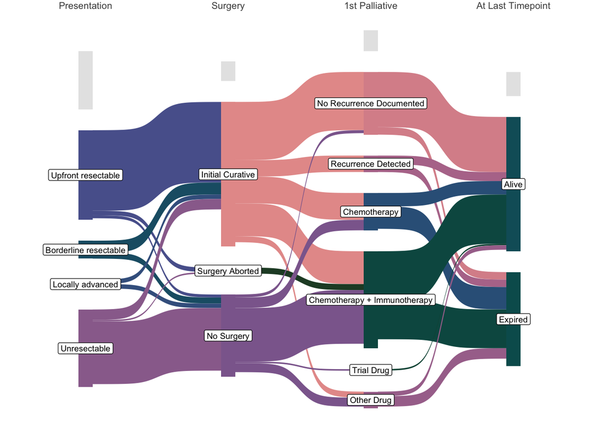

```r
alluvial$second_palliative[alluvial$Reason_for_going_off_first_line_palliative_chemotherapy_choiceDisease_progression_on_treatment == 'Checked' & alluvial$second_palliative == ''] <- "Progression Detected"
alluvial$second_palliative[alluvial$Reason_for_going_off_first_line_palliative_chemotherapy_choiceComplete == 'Checked' & alluvial$second_palliative == ''] <- "1L Complete"
alluvial$second_palliative[alluvial$Reason_for_going_off_first_line_palliative_chemotherapy_choiceOngoing == 'Checked' & alluvial$second_palliative == ''] <- "1L On-Going"
alluvial$second_palliative[alluvial$Reason_for_going_off_first_line_palliative_chemotherapy_choiceFunctional_decline == 'Checked' & alluvial$second_palliative == ''] <- "Decline"
alluvial$second_palliative[alluvial$Reason_for_going_off_first_line_palliative_chemotherapy_choicePatient_Request == 'Checked' & alluvial$second_palliative == ''] <- "Patient Request"
alluvial$second_palliative[alluvial$Reason_for_going_off_first_line_palliative_chemotherapy_choiceTreatment_toxicities == 'Checked' & alluvial$second_palliative == ''] <- "1L Toxicity"

alluvial$progression <- NA
alluvial$progression[alluvial$second_palliative == "No Recurrence Documented"] <- "No Recurrence Documented"
alluvial$progression[alluvial$second_palliative %in% c("FOLFOX", "Other fluoropyrimidine-based",  "Progression Detected",  "Other Drug" ,"Trial Drug" , "GemCis + Durva" , "GemCis"   )] <- "Progression Detected"
alluvial$progression[alluvial$second_palliative %in% c("1L Complete", "1L Toxicity", "1L On-Going"  )] <- "No Progression"
alluvial$progression[alluvial$second_palliative %in% c("Expired w/o 2L"  )] <- "Expired w/o 2L"

alluvial$second_palliative[alluvial$progression == "No Progression"] <- "No Progression"
alluvial$second_palliative[is.na(alluvial$progression) & alluvial$second_palliative == ''] <- NA

alluvial$Status[alluvial$Status == ""] <- "Unknown"



alluvial$Type_of_Neoadjuvant_Chemotherapy_specific <- alluvial$Type_of_Neoadjuvant_Chemotherapy
alluvial$Type_of_Neoadjuvant_Chemotherapy[alluvial$Type_of_Neoadjuvant_Chemotherapy %in% c("GemCis + Durva", "Tremelimumab + Durvalumab","Atezolizumab + Bevacizumab")] <- "Chemotherapy + Immunotherapy"
alluvial$Type_of_Neoadjuvant_Chemotherapy[alluvial$Type_of_Neoadjuvant_Chemotherapy %in% c("GemCis","Capecitabine")] <- "Chemotherapy"

alluvial$Adjuvant_Chemotherapy_specific <- alluvial$Adjuvant_Chemotherapy
alluvial$Adjuvant_Chemotherapy[alluvial$Adjuvant_Chemotherapy %in% c("GemCis + Durva")] <- "Chemotherapy + Immunotherapy"
alluvial$Adjuvant_Chemotherapy[alluvial$Adjuvant_Chemotherapy %in% c("GemCis", "Gem","Capecitabine","Fluoropyrimidine-based","Gemcitabine + platnium")] <- "Chemotherapy"
alluvial$Adjuvant_Chemotherapy[alluvial$Adjuvant_Chemotherapy %in% c("Durva")] <- "Immunotherapy"
alluvial$Adjuvant_Chemotherapy[alluvial$Adjuvant_Chemotherapy %in% c("capecitabine + rilvegostomig")] <-  "Trial Drug"

alluvial$first_palliative_specific <- alluvial$first_palliative
alluvial$first_palliative[alluvial$first_palliative %in% c("GemCis + Durva")] <- "Chemotherapy + Immunotherapy"
alluvial$first_palliative[alluvial$first_palliative %in% c("Gem","GemCis","Other fluoropyrimidine-based","FOLFOX","Capecitabine"  )] <- "Chemotherapy"
alluvial$first_palliative[alluvial$first_palliative %in% c("Pemigatinib"  )] <- "Other Drug"


alluvial$second_palliative_specific <- alluvial$second_palliative
alluvial$second_palliative[alluvial$second_palliative %in% c("GemCis + Durva")] <- "Chemotherapy + Immunotherapy"
alluvial$second_palliative[alluvial$second_palliative %in% c("FOLFOX","Other fluoropyrimidine-based","GemCis","Capecitabine" )] <- "Chemotherapy"
alluvial$second_palliative[alluvial$second_palliative %in% c("Pemigatinib"  )] <- "Other Drug"

alluvial.core <- alluvial %>% dplyr::select(Study_ID, Disease_status_at_presentation, Type_of_Surgery, first_palliative, Status)
alluvial.inc <- alluvial %>% filter(is.na(first_palliative) & !is.na(Type_of_Surgery))

sankey_data <- alluvial %>%
  make_long(Disease_status_at_presentation,
            Type_of_Surgery,
            first_palliative,
            Status)

sankey_data[sankey_data == 'Unknown'] <- NA

level_order <- rev(c(
  "Alive"                  ,
  "Upfront resectable" ,
  "Borderline resectable"       ,
  "No Recurrence Documented"     ,
  "Initial Curative"     ,
  "No Progression",

  "Unknown"                  ,

  'Recurrence Detected',
  "Progression Detected",

  "Chemotherapy",
  "Chemotherapy + Immunotherapy",
  "Immunotherapy",

  "Trial Drug"                ,
  "Other Drug"                ,

  "Surgery Aborted",
  "Expired w/o 2L" ,
  'No Adjuvant',
  "No Neoadjuvant",
  "No Surgery",
  "Locally advanced"  ,
  "Unresectable"         ,
  "Expired"            ,
  NA

))
n.levels <- length(level_order)

sankey_data$node    <- factor(sankey_data$node, levels = level_order)
sankey_data$next_node    <- factor(sankey_data$next_node, levels = level_order)

sankey_plot <-
ggplot(sankey_data, aes(x = x,
                        next_x = next_x,
                        node = node,
                        next_node = next_node,
                        fill = factor(node),
                        label = node)) +
  geom_sankey() +
  scale_fill_manual(values = pnw_palette(name="Starfish", n=n.levels )[sample(c(1:n.levels), n.levels, replace =F)], na.value = 'grey90') +

  geom_sankey_label(size=2.5, fill="white")+
  theme_sankey(base_size = 10)+
  scale_x_discrete( position = "top", c(
    'Disease_status_at_presentation',
    'Type_of_Surgery',
    'first_palliative',
    'Status'
  ), labels = c('Presentation','Surgery','1st Palliative','At Last Timepoint')) +

  theme(legend.position = "none",
        plot.background = element_blank(),
        panel.background = element_blank(),
        plot.margin = unit(c(0, 0, 0, 0), "mm"),

        axis.title.x = element_blank())+ coord_cartesian(clip = "off")
sankey_plot
```

```r
ggsave(paste0(basedir, "/results/fig/FIG1b.mini.clinical.sankey.svg"),plot =sankey_plot, device = "svg",width = 90, height = 55, units='mm' , dpi=72 )
alluvial %>% group_by(Type_of_Surgery) %>% tally()
```

```
## # A tibble: 5 × 2
##   Type_of_Surgery      n
##   <chr>            <int>
## 1 Initial Curative    97
## 2 No Surgery          55
## 3 Surgery Aborted      4
## 4 Unknown              1
## 5 <NA>                12
```

```r
alluvial %>% filter(Type_of_Surgery  == 'Initial Curative') %>% group_by(Adjuvant_Chemotherapy) %>% tally()
```

```
## # A tibble: 6 × 2
##   Adjuvant_Chemotherapy            n
##   <chr>                        <int>
## 1 Chemotherapy                    55
## 2 Chemotherapy + Immunotherapy     2
## 3 Immunotherapy                    2
## 4 No Adjuvant                     34
## 5 Trial Drug                       1
## 6 <NA>                             3
```

```r
alluvial %>% group_by(first_palliative) %>% tally()
```

```
## # A tibble: 8 × 2
##   first_palliative                 n
##   <chr>                        <int>
## 1 Chemotherapy                    25
## 2 Chemotherapy + Immunotherapy    65
## 3 Ivosidenib                       1
## 4 No Recurrence Documented        42
## 5 Other Drug                      11
## 6 Recurrence Detected             11
## 7 Trial Drug                       1
## 8 <NA>                            13
```

```r
alluvial %>% group_by(first_palliative, first_palliative_specific) %>% tally()
```

```
## # A tibble: 12 × 3
## # Groups:   first_palliative [8]
##    first_palliative             first_palliative_specific     n
##    <chr>                        <chr>                     <int>
##  1 Chemotherapy                 Capecitabine                  3
##  2 Chemotherapy                 FOLFOX                        5
##  3 Chemotherapy                 Gem                           5
##  4 Chemotherapy                 GemCis                       12
##  5 Chemotherapy + Immunotherapy GemCis + Durva               65
##  6 Ivosidenib                   Ivosidenib                    1
##  7 No Recurrence Documented     No Recurrence Documented     42
##  8 Other Drug                   Other Drug                   10
##  9 Other Drug                   Pemigatinib                   1
## 10 Recurrence Detected          Recurrence Detected          11
## 11 Trial Drug                   Trial Drug                    1
## 12 <NA>                         <NA>                         13
```

## Analyze cases by anatomical location of the primary tumor

```r
locations <- all.clinic %>%
  dplyr::select(
    starts_with("Study_ID") |
      starts_with("Anatomical_Location") |
      starts_with("Specify_other_tumour_location") |
      starts_with("Specify_Extrahepatic")
  ) %>% reshape2::melt(id.vars = c('Study_ID')) %>%
  filter(value %ni% c('Unchecked','') & variable != 'Other' & !is.na(value))

locations$variable <- gsub('Anatomical_Location_choice','',locations$variable)

locations$variable[locations$value %in% c('Combined HCC/CCA (solitary segment 8)','Combined HCC/CCA and CCA','mixed CCA-HCC','Combined HCC-CCA','HCC-CCA','Mixed HCC-CCA')] <- 'HCC-CCA'
locations$variable[locations$value %in% c('dCCA or GB/cystic duct','GB vs iCCA','CCA NOS')] <- 'CCA NOS'


primary_location <- locations %>% filter(variable %in% c('Extrahepatic_CCA_eCCA','Gallbladder','Intrahepatic_CCA_iCCA', 'CCA NOS', 'HCC-CCA')) %>%
  group_by(Study_ID) %>%
  summarise(variable = str_c(variable, collapse = "+"), .groups = "drop")
unique(primary_location$variable)
```

```
## [1] "Gallbladder"
## [2] "Intrahepatic_CCA_iCCA"
## [3] "Extrahepatic_CCA_eCCA"
## [4] "Extrahepatic_CCA_eCCA+Gallbladder+CCA NOS"
## [5] "Extrahepatic_CCA_eCCA+Gallbladder"
## [6] "HCC-CCA"
## [7] "CCA NOS"
## [8] "Intrahepatic_CCA_iCCA+HCC-CCA"
```

```r
primary_location$variable[primary_location$variable == "Intrahepatic_CCA_iCCA+HCC-CCA"] <- "HCC-CCA"
primary_location$variable[primary_location$variable == "Extrahepatic_CCA_eCCA+Gallbladder+CCA NOS"] <- "CCA NOS"
primary_location$variable[primary_location$variable == "Extrahepatic_CCA_eCCA+Gallbladder"] <- "CCA NOS"
primary_location %>% group_by(variable) %>% tally()
```

```
## # A tibble: 5 × 2
##   variable                  n
##   <chr>                 <int>
## 1 CCA NOS                   4
## 2 Extrahepatic_CCA_eCCA    32
## 3 Gallbladder              18
## 4 HCC-CCA                  11
## 5 Intrahepatic_CCA_iCCA   104
```

```r
primary_location %>% group_by(variable) %>% tally() %>% summarise(sum_n=sum(n))
```

```
## # A tibble: 1 × 1
##   sum_n
##   <int>
## 1   169
```

```r
eCCA.loc <- locations %>% filter( str_starts(variable, "Specify_Extrahepatic_CCA_choice"))
eCCA.loc$variable <- gsub('Specify_Extrahepatic_CCA_choice','',eCCA.loc$variable)

eCCA.loc <- reshape2::dcast(eCCA.loc, Study_ID ~ variable)
eCCA.loc$eCCA <- NA
eCCA.loc$eCCA[eCCA.loc$Distal_CCA_dCCA == 'Checked'] <- 'Distal_CCA_dCCA'
eCCA.loc$eCCA[eCCA.loc$Common_bile_duct == 'Checked'] <- 'Distal_CCA_dCCA'
eCCA.loc$eCCA[eCCA.loc$PerihilarHilar_Klatskins_pCCA == 'Checked' & is.na(eCCA.loc$eCCA)] <- 'Perihilar_CCA_pCCA'
eCCA.loc$eCCA[eCCA.loc$Common_hepatic_duct == 'Checked' & is.na(eCCA.loc$eCCA)] <- 'Perihilar_CCA_pCCA'

primary_location <- left_join(primary_location, eCCA.loc %>% dplyr::select(Study_ID, eCCA))
primary_location$variable[!is.na(primary_location$eCCA)] <- primary_location$eCCA[!is.na(primary_location$eCCA)]

primary_location_tally <- primary_location %>% group_by(variable) %>% tally()
primary_location %>% group_by(Study_ID) %>% tally() %>% filter(n>1)
```

```
## # A tibble: 0 × 2
## # ℹ 2 variables: Study_ID <chr>, n <int>
```

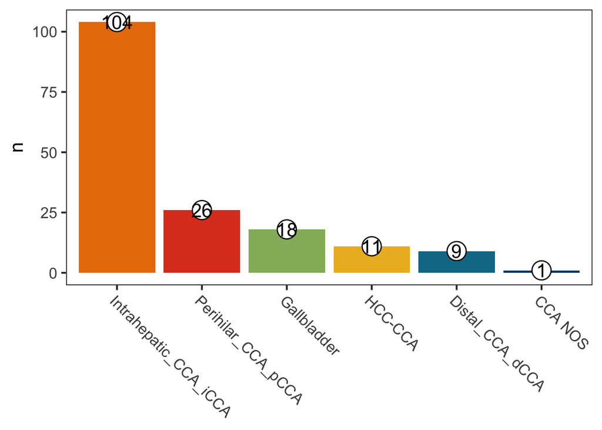

```r
ggplot(primary_location_tally, aes(x=reorder(variable, -n), y=n)) +
  geom_bar(stat='identity',aes(fill=variable)) +
  geom_point(size=7, color = 'white', shape=16) +
  geom_point(size=7,  shape=1) +
  geom_text(aes(label=n)) +
  scale_fill_manual(values = pnw_palette(name="Bay", n=length(unique(primary_location_tally$variable)) ), na.value = 'grey90') +
  guides(fill='none')+
  theme_bw(base_size=16) +
  theme(axis.text.x = element_text(hjust = -0, angle = -45),
        axis.title.x = element_blank(),
        panel.grid = element_blank()

  )
```

```r
primary_location_tally %>% summarise(sum_n = sum(n))
```

```
## # A tibble: 1 × 1
##   sum_n
##   <int>
## 1   169
```

## Identify sequencing specimen

For cases where more than one specimen underwent WGTS, we make sure the right part of the clinical story is analyzed

```r
EXTRA_IDs =  c('BTC_0160'='LBR-0410','HBTHCC_2168'='LBR-0368' )

lbr.samples <- lbr.clinic.all %>% filter(!is.na(Repeat_Instrument ) | Study_ID == 'LBR-0410')

#lbr.samples$Study_ID <- sprintf("LBR-%04d", lbr.samples$Study_ID)
lbr.samples$BTC_ID <- gsub('-','_',lbr.samples$BTC_ID)
lbr.samples$BTC_ID <- gsub('__','_',lbr.samples$BTC_ID)

all.samples <- align_df2_to_df1(df1=lbr.samples, df2=non.lbr.clinic)

all.samples <- all.samples %>% filter(Study_ID %in% BTC_clinical.tumours$`Study ID` | Study_ID %in% BTC_clinical.tumours$Donor | Study_ID %in% EXTRA_IDs)
length(unique(all.samples$Study_ID))
```

```
## [1] 169
```

```r
all.samples <- all.samples %>% dplyr::select(Study_ID, BTC_ID, Date_of_tissue,
                                             Site_of_tissue,
                                             Specify_other_site_of_tissue,
                                             Procedure_Type,

                                             Timepoint1170, ## most complete of several columns with same name

                                            Specify_procedure,
                                            LCM_Complete
                               ) %>% unique() %>%
                                left_join(
                                primary_location ,

                                by=c('Study_ID'='Study_ID')

                              )

names(all.samples)[names(all.samples) == 'Timepoint1170'] <- 'Timepoint'

all.samples$BTC_ID <- toupper(all.samples$BTC_ID)
all.samples$BTC_ID[all.samples$BTC_ID == 'BTC_00017'] <- 'BTC_0017'
all.samples$BTC_ID[all.samples$BTC_ID == '(BTC_0029)'] <- 'BTC_0029'

all.samples$BTC_ID[all.samples$Study_ID == 'LBR-0074'] <- 'BTC_0117'
all.samples$BTC_ID[all.samples$Study_ID == 'LBR-0033'] <- 'BTC_0113'
all.samples$BTC_ID[all.samples$Study_ID == 'LBR-0383'] <- 'BTC_0197'
all.samples$BTC_ID[all.samples$Study_ID == 'LBR-0410'] <- 'BTC_0160'
all.samples$BTC_ID[all.samples$Study_ID == 'LBR-0368'] <- 'HBTHCC_2168'

## remove second samples where donor has two
all.samples %>% group_by(BTC_ID) %>% tally() %>% arrange(BTC_ID) %>% filter(n > 1)
```

```
## # A tibble: 21 × 2
##    BTC_ID       n
##    <chr>    <int>
##  1 BTC_0014     2
##  2 BTC_0015     2
##  3 BTC_0017     2
##  4 BTC_0025     2
##  5 BTC_0028     2
##  6 BTC_0029     3
##  7 BTC_0033     3
##  8 BTC_0034     2
##  9 BTC_0049     2
## 10 BTC_0064     2
## # ℹ 11 more rows
```

```r
length(unique(all.samples$Study_ID))
```

```
## [1] 169
```

```r
all.samples <- all.samples %>%  filter(!(BTC_ID == 'BTC_0014' & LCM_Complete == 'No'))
all.samples <- all.samples %>%  filter(!(BTC_ID == 'BTC_0015' & Procedure_Type == 'Biopsy'))
all.samples <- all.samples %>%  filter(!(BTC_ID == 'BTC_0017' & Timepoint == 'Not applicable'))
all.samples <- all.samples %>%  filter(!(BTC_ID == 'BTC_0025' & Timepoint == 'Progression'))
all.samples <- all.samples %>%  filter(!(BTC_ID == 'BTC_0028' & is.na(Site_of_tissue)))
all.samples <- all.samples %>%  filter(!(BTC_ID == 'BTC_0029' & LCM_Complete == 'No'))
all.samples <- all.samples %>%  filter(!(BTC_ID == 'BTC_0029' & Procedure_Type == 'Biopsy'))
all.samples <- all.samples %>%  filter(!(BTC_ID == 'BTC_0033' & Timepoint == 'Progression'))
all.samples <- all.samples %>%  filter(!(BTC_ID == 'BTC_0034' & Timepoint == 'Progression'))
all.samples <- all.samples %>%  filter(!(BTC_ID == 'BTC_0049' & LCM_Complete == 'No' )) #BTC_0049, the 2019 sample is not LCM
all.samples <- all.samples %>%  filter(!(BTC_ID == 'BTC_0064' & Procedure_Type == 'Biopsy'))
all.samples <- all.samples %>%  filter(!(BTC_ID == 'BTC_0071' & Procedure_Type == 'Biopsy'))
all.samples <- all.samples %>%  filter(!(BTC_ID == 'BTC_0081' & LCM_Complete == 'No'))
all.samples <- all.samples %>%  filter(!(BTC_ID == 'BTC_0087' & Timepoint == 'Progression'))
all.samples <- all.samples %>%  filter(!(BTC_ID == 'BTC_0100' & LCM_Complete == 'No'))
all.samples <- all.samples %>%  filter(!(BTC_ID == 'BTC_0117' & is.na(Procedure_Type)))
all.samples <- all.samples %>%  filter(!(BTC_ID == 'BTC_0122' & Specify_procedure == 'Living donor liver transplant - Gallbladder lesion')) #both fail cellularity
all.samples <- all.samples %>%  filter(!(BTC_ID == 'BTC_0124' & Timepoint == 'Progression'))
all.samples <- all.samples %>%  filter(!(BTC_ID == 'BTC_0127' & Timepoint == 'Recurrence'))
all.samples <- all.samples %>%  filter(!(BTC_ID == 'BTC_0142' & Site_of_tissue == 'Other')) # fail cellularity
all.samples <- all.samples %>%  filter(!(BTC_ID == 'BTC_0152' & LCM_Complete == 'No'))

all.samples <- all.samples %>%  filter(!(BTC_ID == 'BTC_0197' & is.na(Procedure_Type)))

all.samples %>% group_by(BTC_ID) %>% tally() %>% arrange(desc(n)) %>% filter(n > 1)
```

```
## # A tibble: 0 × 2
## # ℹ 2 variables: BTC_ID <chr>, n <int>
```

```r
length(unique(all.samples$Study_ID))
```

```
## [1] 169
```

```r
all.samples$Sample_Progression <- NA
all.samples$Sample_Progression[all.samples$Procedure_Type == 'Surgical Resection'] <- 'Primary'
all.samples$Sample_Progression[all.samples$Procedure_Type == 'Biopsy' & all.samples$Site_of_tissue %in% c('Other','Peritoneum','Lung')] <- 'Metastasis'
all.samples$Sample_Progression[all.samples$Procedure_Type == 'Biopsy' &
                                 all.samples$Site_of_tissue == 'Liver' &
                                 all.samples$variable %in% c('Distal_CCA_dCCA','Gallbladder','Perihilar_CCA_pCCA')] <- 'Metastasis'

all.samples$Sample_Progression[all.samples$Procedure_Type == 'Biopsy' &
                                 all.samples$Site_of_tissue == 'Liver' &
                                 all.samples$variable %in% c('Intrahepatic_CCA_iCCA','HCC-CCA')] <- 'Primary'

all.samples$Site_of_tissue[all.samples$Specify_other_site_of_tissue == "Paravertebral and Liver Biopsy"] <- 'Spine'
all.samples$Site_of_tissue[all.samples$Specify_other_site_of_tissue %in% c("Neck - Lymph Node")] <- 'Neck'
all.samples$Site_of_tissue[all.samples$Specify_other_site_of_tissue %in% c("Abdomen","LAPAROSCOPIC ABDOMINAL LYMPH NODE BIOPSY")] <- 'Abdomen'
all.samples$Site_of_tissue[all.samples$Site_of_tissue == 'Peritoneum'] <- 'Abdomen'

all.samples <- all.samples %>%
  mutate(Sample_Progression = if_else(
    startsWith(Study_ID, "BTC_9"),
    'Primary',
    Sample_Progression
  ))

all.samples <- all.samples %>%
  mutate(Procedure_Type = if_else(
    startsWith(Study_ID, "BTC_9"),
    "Surgical Resection",
    Procedure_Type
  ))


all.samples %>% group_by(Sample_Progression) %>%  tally()
```

```
## # A tibble: 3 × 2
##   Sample_Progression     n
##   <chr>              <int>
## 1 Metastasis            27
## 2 Primary              133
## 3 <NA>                   9
```

```r
met.tally <- all.samples %>% filter(Sample_Progression == 'Metastasis') %>%
  group_by(variable, Site_of_tissue, Specify_other_site_of_tissue) %>% tally() #%>% arrange(desc(n))

met.tally %>% dplyr::select(variable, Site_of_tissue, n) %>% data.frame()
```

```
##                 variable Site_of_tissue  n
## 1        Distal_CCA_dCCA        Abdomen  1
## 2        Distal_CCA_dCCA          Liver  2
## 3            Gallbladder        Abdomen  1
## 4            Gallbladder          Liver 11
## 5  Intrahepatic_CCA_iCCA           Lung  1
## 6  Intrahepatic_CCA_iCCA          Spine  1
## 7     Perihilar_CCA_pCCA        Abdomen  1
## 8     Perihilar_CCA_pCCA        Abdomen  1
## 9     Perihilar_CCA_pCCA        Abdomen  1
## 10    Perihilar_CCA_pCCA          Liver  6
## 11    Perihilar_CCA_pCCA           Neck  1
```

```r
met.tally.df <- met.tally %>% dplyr::select(variable, Site_of_tissue, n) %>% data.frame()
names(met.tally.df) <- c('location','metastasis','frequency')

met.tally.df$location[met.tally.df$location == "Intrahepatic_CCA_iCCA"] <- 'Intrahepatic'
met.tally.df$location[met.tally.df$location == "Perihilar_CCA_pCCA"] <- 'Perihilar'
met.tally.df$location[met.tally.df$location == "Distal_CCA_dCCA"] <- 'Distal'
met.tally.df$location <- factor(met.tally.df$location, levels = c('Intrahepatic', 'Perihilar',  'Distal', 'Gallbladder'))

locations <- met.tally.df %>%  distinct(location) %>% arrange(desc(location)) %>% mutate(x_org = 1, y_org = seq(1, n()))
metastases <- met.tally.df %>% distinct(metastasis) %>% mutate(x_loc = 3, y_loc = seq(1, n()))

sum(met.tally.df$frequency)
```

```
## [1] 27
```

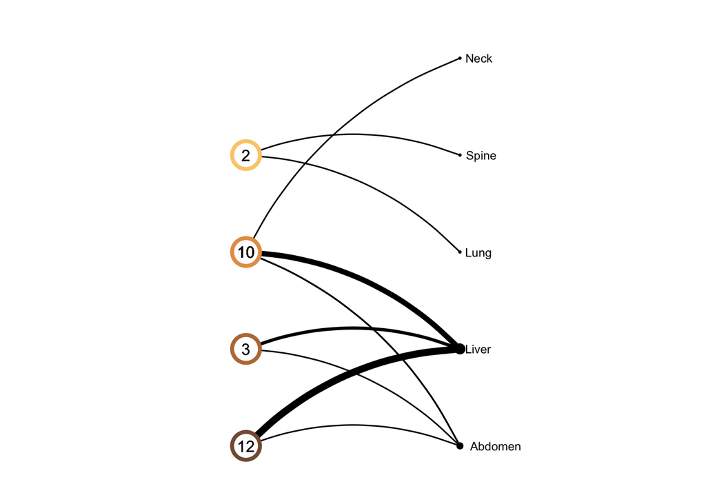

```r
# Merge positions
plot_data <- met.tally.df %>%
  left_join(locations, by = "location") %>%
  left_join(metastases, by = "metastasis")

plot_data <- plot_data %>% group_by(location, x_org, y_org) %>% mutate(n.org = sum(frequency))
plot_data <- plot_data %>% group_by(metastasis) %>% mutate(n.met = sum(frequency))

met.locations.plot <-
ggplot() +

  geom_text(data = metastases, aes(x = x_loc, y = y_loc, label = metastasis), hjust = -0.2, size=3) +
  geom_curve(data = plot_data,
             curvature = -0.2,
               aes(x = x_org, y = y_org, xend = x_loc, yend = y_loc, size = frequency),
              show.legend = FALSE
               #arrow = arrow(length = unit(3, "mm")),
              ) +

  geom_point(data = locations, aes(x = x_org, y = y_org), size = 8, color='white') +
  geom_text(data = plot_data, aes(x = x_org, y = y_org, label = n.org),  size=4 ) +

  geom_point(data = locations, aes(x = x_org, y = y_org, color=location), size = 8, shape=1, stroke = 2) +
  geom_point(data = plot_data, aes(x = x_loc, y = y_loc, size = n.met), color='black') +


  scale_color_manual(values = c("Perihilar" = "#e59d54ff",
                                "Intrahepatic" = "#fbcc7aff",
                                "Distal" = "#ba7a44ff",
                                "Gallbladder" = "#855b40ff")) +
  scale_size(range = c(0.5, 3)) +
  theme_void(base_size=10) +
  xlim(-1, 5)+
  guides(color='none', size='none') +
  coord_cartesian(clip = "off")+
  scale_y_continuous(expand = expansion(mult = 0.15))


# Plot with arrows
met.locations.plot
```

```r
ggsave(paste0(basedir, "/results/fig/FIG1d.met.locations.svg"),plot =

met.locations.plot
, device = "svg",width = 70, height = 45, units = 'mm' )
```

## Tumour features

Here we are looking at features of the tumour from which the WGTS specimen is derived, things like mets, histology etc.

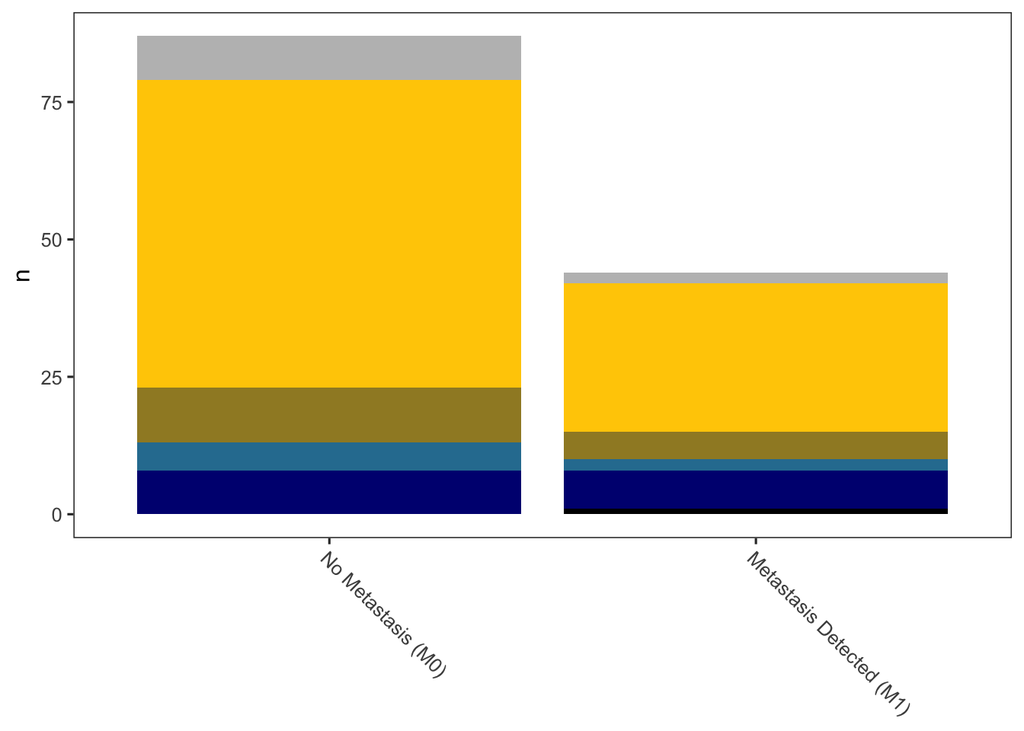

```r
more.tumour.ft <- all.clinic %>% dplyr::select(
  Study_ID, Histology, Other_Histology,

  #is more complete
  Grade1435,    Grade817,

  Other_Grade,
    T_at_diagnosis, N_at_diagnosis, M_at_diagnosis,
    Overall_Stage_at_Diagnosis, Greatest_dimension_centimeters,
    Tumour_growth_pattern)

names(more.tumour.ft)[names(more.tumour.ft) == 'Grade817'] <- 'Grade_at_diagnosis'
names(more.tumour.ft)[names(more.tumour.ft) == 'Grade1435'] <- 'Grade_at_surgery'

more.tumour.ft[more.tumour.ft == ''] <- NA
more.tumour.ft[more.tumour.ft == 'Unknown'] <- NA
more.tumour.ft[more.tumour.ft == 'Not available'] <- NA
more.tumour.ft[more.tumour.ft == 'Not stated'] <- NA
more.tumour.ft[more.tumour.ft == 'N/A'] <- NA
more.tumour.ft[more.tumour.ft == 'Other'] <- NA



more.tumour.ft <-  left_join(more.tumour.ft, all.samples)
more.tumour.ft$Histology[more.tumour.ft$variable == 'HCC-CCA'] <- 'HCC-CCA'
more.tumour.ft$Other_Histology[more.tumour.ft$variable == 'HCC-CCA'] <- 'HCC-CCA'
more.tumour.ft$Histology[more.tumour.ft$Histology %in% c('Not available','')] <- NA

more.tumour.ft$Other_Histology[more.tumour.ft$Histology != 'Other'] <- NA

more.tumour.ft$Histology[more.tumour.ft$Histology == 'Other' & !is.na(more.tumour.ft$Histology)] <- paste0('Other - ', more.tumour.ft$Other_Histology[more.tumour.ft$Histology == 'Other' & !is.na(more.tumour.ft$Histology)])




# Stage - cM0 v 1
cM.tally <- more.tumour.ft %>% group_by(M_at_diagnosis, variable) %>% tally()

cM.tally$variable[cM.tally$variable == "Intrahepatic_CCA_iCCA"] <- 'Intrahepatic'
cM.tally$variable[cM.tally$variable == "Perihilar_CCA_pCCA"] <- 'Perihilar'
cM.tally$variable[cM.tally$variable == "Distal_CCA_dCCA"] <- 'Distal'
cM.tally$variable <- factor(cM.tally$variable, levels = c('HCC-CCA','Intrahepatic', 'Perihilar',  'Distal', 'Gallbladder','CCA NOS'))

cM.tally$met_long <- NA
cM.tally$met_long[cM.tally$M_at_diagnosis == 'M0'] <- 'No Metastasis (M0)'
cM.tally$met_long[cM.tally$M_at_diagnosis == 'M1'] <- 'Metastasis Detected (M1)'


ggplot(cM.tally %>% filter(!is.na(met_long)), aes(x=reorder(met_long, -n), y=n)) +
  geom_bar(stat='identity',aes(fill=variable)) +
  theme_bw(base_size=12) +
  theme(axis.text.x = element_text(hjust = -0, angle = -45),
        axis.title.x = element_blank(),
        panel.grid = element_blank()

  )+guides(fill='none')+

  scale_fill_manual(values = c("Perihilar" = "#a0892cff",
                                "Intrahepatic" = "#ffcc00ff",
                                "Distal" = "#2c7da0ff",
                                "Gallbladder" = "#000080ff",
                               'HCC-CCA' = 'grey',
                               'CCA NOS' = 'black'))
```

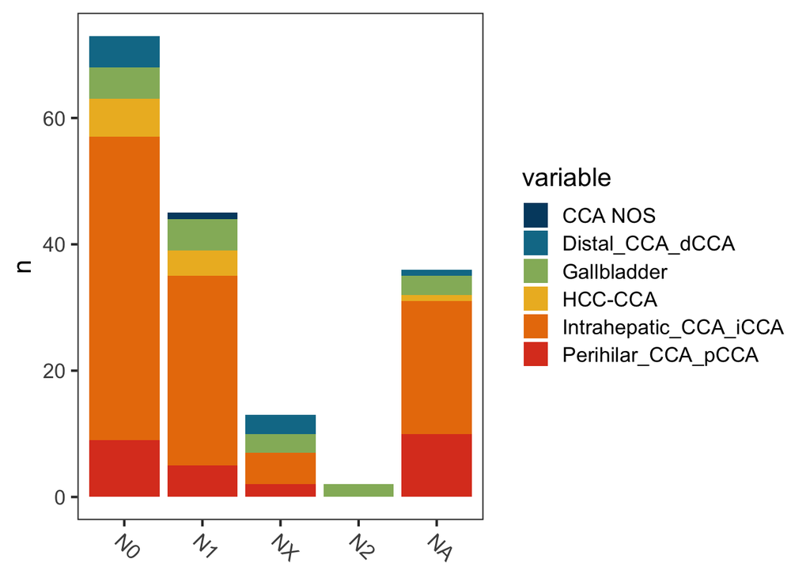

```r
# Stage - pN0 v 1-2 (ie not y- ie exclude pre-treated)

nodes.tally <- more.tumour.ft %>% group_by(N_at_diagnosis, variable) %>% tally()

ggplot(nodes.tally, aes(x=reorder(N_at_diagnosis, -n), y=n)) +
  geom_bar(stat='identity',aes(fill=variable)) +
  scale_fill_manual(values = pnw_palette(name="Bay", n=length(unique(nodes.tally$variable)) ), na.value = 'grey90') +
  theme_bw(base_size=16) +
  theme(axis.text.x = element_text(hjust = -0, angle = -45),
        axis.title.x = element_blank(),
        panel.grid = element_blank()

  )
```

```r
sum(nodes.tally$n)
```

```
## [1] 169
```

## Organize timeline

Similar to the alluvial, we are organizing the data such that it follows a timeline, ie events are relative to date of diagnosis. These relative dates also downgrade the security level on the data. We can also check this way whether the tumor specimen we chose for the patient comes before or after treatment starts.

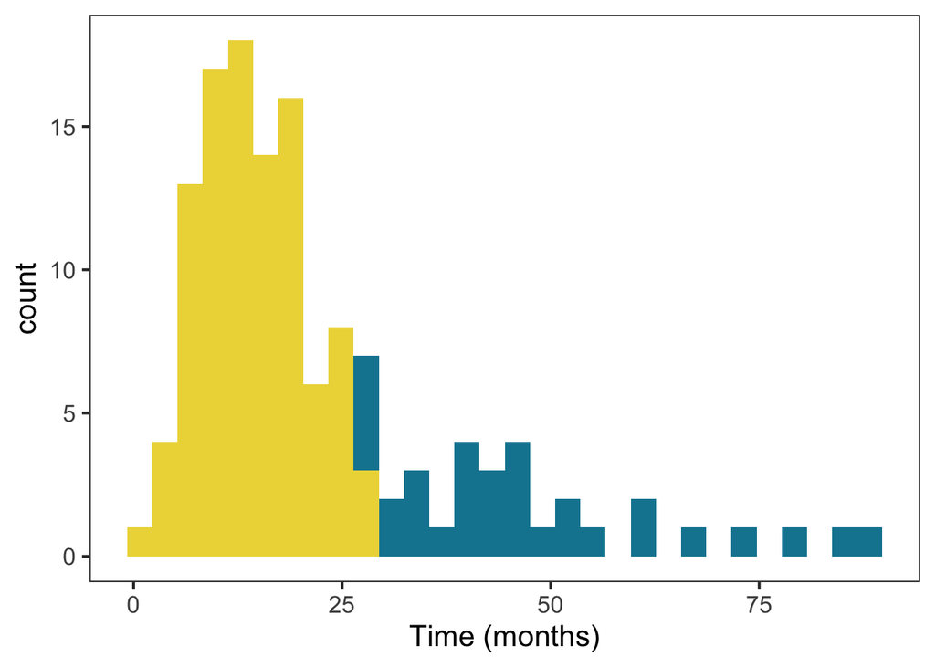

```r
timeline <- all.clinic %>% dplyr::select(
    Study_ID,
    Date_of_radiological_diagnosis,
    Date_of_first_histological_diagnosis,

    Date_Neoadjuvant_Chemotherapy_Started,
    Date_Neoadjuvant_Chemotherapy_Ended,

    Date_of_Surgery,

    Adjuvant_Chemotherapy_Start_Date,
    Adjuvant_Chemotherapy_End_Date,

    Date_of_recurrence,

    Date_of_first_infusion_of_first_line_palliative_chemotherapy,
    Date_of_last_infusion_of_first_line_palliative_chemotherapy,
    Date_Durvalumab_maintenance_began,
    Date_of_disease_progression1671,
    Date_of_first_infusion_of_first_line_palliative_immunotherapy1653,
    Date_of_last_infusion_of_first_line_palliative_immunotherapy1655,
    Date_palliative_radiation_started,
    Date_palliative_radiation_ended,
    Date_of_death,
    Date_of_last_follow_up
  ) %>%
  left_join(all.samples %>% dplyr::select(Study_ID, Date_of_tissue)) %>%
  mutate(across(everything(), as.character))
##Hop cohort is all treatment naive surgical specimen

timeline <- timeline %>%
  mutate(Date_of_tissue = if_else(
    startsWith(Study_ID, "BTC"),
    Date_of_Surgery,
    Date_of_tissue
  ))



names(timeline)[names(timeline) == 'Date_of_disease_progression1671'] <- 'Date_of_disease_progression'
names(timeline)[names(timeline) == 'Date_of_first_infusion_of_first_line_palliative_immunotherapy1653'] <- 'Date_of_first_infusion_of_first_line_palliative_immunotherapy'
names(timeline)[names(timeline) == 'Date_of_last_infusion_of_first_line_palliative_immunotherapy1655'] <- 'Date_of_last_infusion_of_first_line_palliative_immunotherapy'

timeline <- timeline %>% mutate(across(everything(), ~ ifelse(. %in% c('','Not applicable','Unknown','Not available'), NA, .)))

timeline <- cbind.data.frame(timeline[,c(1)], fix_excel_dates(df=timeline[,-c(1)]))

timeline <- timeline %>%
  mutate(earliest_diagnosis = pmin(Date_of_radiological_diagnosis, Date_of_first_histological_diagnosis, na.rm = TRUE)) %>%
  mutate(latest_date = pmax(Date_of_last_follow_up, Date_of_death, na.rm = TRUE))

timeline.rel <- timeline %>%
  mutate(across(
    .cols = where(lubridate::is.Date) & !matches("Study_ID|earliest_diagnosis"),
    .fns = ~ as.numeric(. - earliest_diagnosis) / 30,
    .names = "relative_{.col}"
  )) %>%
  dplyr::select(
    starts_with("Study_ID") |
      starts_with("relative_")
  )


timeline.rel <- timeline.rel %>%
  mutate(across(where(is.numeric), ~ ifelse(. < -10, NA, .)))

timeline.rel$study_f <- factor(timeline.rel$Study_ID,
                               levels = timeline.rel$Study_ID[order(timeline.rel$relative_latest_date, decreasing = T)])

timeline.clusters <- Mclust(na.omit(timeline.rel$relative_latest_date))
timeline.rel$time.class[!is.na(timeline.rel$relative_latest_date)] <- timeline.clusters$classification

timeline.rel$time.class[timeline.rel$time.class == 1] <- 'Normal Response'
timeline.rel$time.class[timeline.rel$time.class == 2] <- 'Long'

ggplot(timeline.rel, aes(x=relative_latest_date, fill=time.class)) + geom_histogram() +
  scale_fill_manual(values = pnw_palette(name="Bay", n=length(unique(timeline.rel$time.class)) )[c(1,2)], na.value = 'grey90') +
  guides(fill='none')+
  theme_bw(base_size=16) +
  theme(
        panel.grid = element_blank()
  ) + labs(x='Time (months)')
```

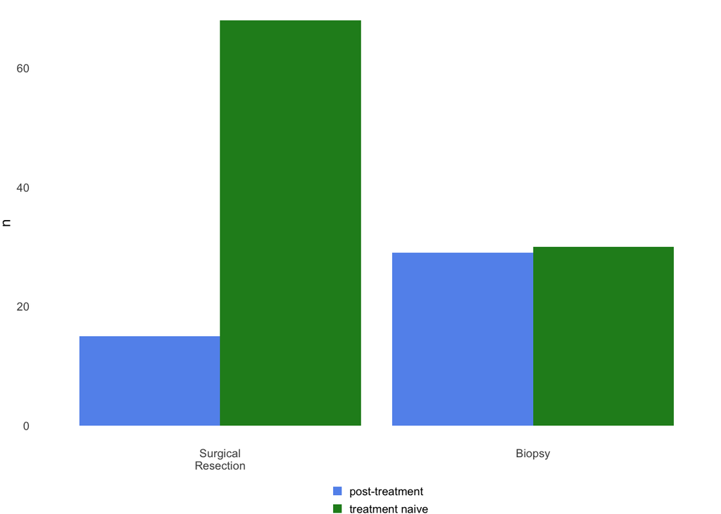

```r
timeline.rel <- timeline.rel %>%
  mutate(
    relative_Date_of_last_follow_up = if_else(
      !is.na(relative_Date_of_death) &
        !is.na(relative_Date_of_last_follow_up) &
        relative_Date_of_last_follow_up < relative_Date_of_death,
      relative_Date_of_death,
      relative_Date_of_last_follow_up
    )
  )


timeline.rel$relative_Date_of_last_follow_up[timeline.rel$relative_Date_of_last_follow_up <0 ] <- NA

timeline.rel$time.class <- factor(timeline.rel$time.class, levels=c("Normal Response", "Long"))

timeline <- timeline %>%
  rowwise() %>%
  mutate(tissue_before_chemo = all(
    Date_of_tissue <= Date_Neoadjuvant_Chemotherapy_Started,
    Date_of_tissue <= Adjuvant_Chemotherapy_Start_Date,
    Date_of_tissue <= Date_of_first_infusion_of_first_line_palliative_chemotherapy,
    na.rm = TRUE
  ),
  tissue_before_immuno = all(
    Date_of_tissue <= Date_of_first_infusion_of_first_line_palliative_immunotherapy,
    na.rm = TRUE
  )) %>%
  ungroup()

all.samples <- left_join(all.samples, timeline %>% dplyr::select(Study_ID, tissue_before_chemo, tissue_before_immuno)) %>%
  left_join(more.tumour.ft %>% dplyr::select(Study_ID, Histology))
write.table( all.samples %>% dplyr::select(Study_ID, BTC_ID, variable, Histology, Sample_Progression, tissue_before_chemo, tissue_before_immuno, LCM_Complete, Timepoint, Site_of_tissue, Procedure_Type),
             file = file.path(basedir,"/results/clinic.sample.info.txt"), row.names = FALSE, quote = FALSE, sep = "\t")


sample.type.tally <- all.samples %>% group_by(tissue_before_chemo, tissue_before_immuno, Procedure_Type) %>% tally()
sample.type.tally$tissue_before_chemo[sample.type.tally$tissue_before_chemo == 'TRUE'] <- 'treatment naive'
sample.type.tally$tissue_before_chemo[sample.type.tally$tissue_before_chemo == 'FALSE'] <- 'post-treatment'

sample.type.tally$Procedure_Type[sample.type.tally$Procedure_Type == "Surgical Resection"] <- "Surgical\nResection"
sample.type.tally$procedure <- factor(sample.type.tally$Procedure_Type, levels=c("Surgical\nResection","Biopsy"))

time_of_specimen.plt <-
      ggplot(sample.type.tally %>% filter(!is.na(procedure)), aes(x = procedure, y = n)) +
         geom_bar(stat = 'identity', aes(fill = tissue_before_chemo), position = position_dodge()) +
         theme_bw(base_size = 10) +
         theme(
          # axis.text.x = element_text(angle = -0),
           axis.title.x = element_blank(),
           plot.background = element_blank(),
           panel.background = element_blank(),
           panel.grid = element_blank(),
           axis.ticks = element_blank(),
           legend.position = 'bottom',
           panel.border = element_blank(),
           legend.margin = margin(0, 0, 0, 0),  # remove extra space around legend
           legend.box.margin = margin(0, 0, 0, 0),  # remove space between legend and plot
           plot.margin = unit(c(0, 0, 0, 0), "mm"),
           legend.key.size = unit(0.5, "lines"),     # smaller legend keys
           legend.text = element_text(size = 8),     # smaller legend text
           legend.title = element_text(size = 9)     # smaller legend title

         ) +
         labs(fill = '') +
         scale_fill_manual(values = c('cornflowerblue', 'forestgreen')) +
         guides(fill = guide_legend(nrow = 2, byrow = TRUE))

time_of_specimen.plt
```

```r
ggsave(paste0(basedir, "/results/fig/FIGS1a.time_of_specimen.svg"),plot =
         time_of_specimen.plt

       , device = "svg",width = 35, height = 49, units = 'mm', dpi=72 )

sum(sample.type.tally$n)
```

```
## [1] 169
```

## The preverbial table 1

Bring together all our new dataframe and summarize the cohort

```r
timeline.outcome <- full_join(alluvial, timeline.rel, by=c('Study_ID'='Study_ID')) %>%
  full_join(more.tumour.ft  %>% dplyr::select(Study_ID, BTC_ID, variable, Grade_at_diagnosis, Grade_at_surgery,
                                              N_at_diagnosis, M_at_diagnosis, Overall_Stage_at_Diagnosis)) %>%

  full_join(all.clinic %>% dplyr::select(Study_ID, CA199, AFP, Albumin, Total_Bilirubin,
                                         Sex_assigned_at_birth,
                                         Race, ECOG,

                                         Have_you_smoked_100_cigarettes_in_your_lifetime,
                                         Have_you_ever_regularly_had_a_drink_of_alcohol_at_least_once_per_week_for_one_year,

                                         Hep_B_Surface_Antigen_HBs_Ag, Hepatitis_B_Surface_Antibody_HBs_Ab,

                                         Has_the_patient_been_diagnosed_with_an_autoimmune_disorder,
                                         Please_specify_what_type_of_liver_disease_related_to_IBD_select_all_that_apply_choicePrimary_Sclerosing_Cholangitis_PSC,
                                         What_type_of_IBD_select_all_that_apply_choiceUlcerative_colitis,
                                         What_type_of_IBD_select_all_that_apply_choiceCrohns_disease,
                                         Do_you_have_a_History_of_Inflammatory_Bowel_Disease_IBD,
                                         Type_of_autoimmune_disorder_choiceInflammatory_bowel_disease,
                                         Type_of_autoimmune_disorder_choicePrimary_sclerosing_cholangitis,
                                         Primary_Biliary_Cholangitis_PBC,
                                         Do_you_have_primary_sclerosing_cholangitis_PSC,
                                         Have_you_ever_been_diagnosed_with_any_of_the_following_related_to_your_diagnosis_of_inflammatory_bowel_disease_IBD_select_all_that_apply_choiceIBD_related_liver_disease,

                                         CRS_Score_if_patient_had_neoadjuvant_therapy,
                                         First_line_palliative_immunotherapy1642,
                                         Cause_of_death,    Specify_other_cause_of_death,
                                         Is_the_patient_diabetic,
                                         BMI, Age_at_first_histological_diagnosis,ALT, AST,

                                         Margins, Overall_Path_Stage, Regional_Lymph_Nodes_pN, Pathologic_M_stage,
                                         Greatest_dimension_centimeters,
                                         PFS_1st_line1693,
                                         PFS_2nd_Line,
                                         Curative_treatment_to_recurrence))
names(timeline.outcome)[names(timeline.outcome) == 'PFS_1st_line1693'] <- 'PFS_1st_line'
names(timeline.outcome)[names(timeline.outcome) == 'First_line_palliative_immunotherapy1642'] <- 'First_line_palliative_immunotherapy'

names(timeline.outcome)[names(timeline.outcome) == 'variable'] <- 'Location'

timeline.outcome$Overall_Stage_at_Diagnosis.precise <- timeline.outcome$Overall_Stage_at_Diagnosis
timeline.outcome$Overall_Stage_at_Diagnosis[timeline.outcome$Overall_Stage_at_Diagnosis %in% c('I','IA','IB','II')] <- 'I & II'
timeline.outcome$Overall_Stage_at_Diagnosis[timeline.outcome$Overall_Stage_at_Diagnosis %in% c('IIIA','IIIB','IIIC')] <- 'III'
timeline.outcome$Overall_Stage_at_Diagnosis[timeline.outcome$Overall_Stage_at_Diagnosis %in% c('IV','IVA','IVB')] <- 'IV'


t1.data <- timeline.outcome
t1.data$cohort <- 'other'
t1.data$cohort[timeline.outcome$Type_of_Surgery %in% c("Initial Curative")] <- 'Surgical'
t1.data$cohort[timeline.outcome$Type_of_Surgery %in% c("No Surgery")] <- 'Unresected'

na_values <- c("No information", "Not available", "Not Done", "Unknown", "Not stated", "Not applicable", "","N/A")

t1.data <- t1.data %>%
  mutate(across(everything(), ~replace(., . %in% na_values, NA)))


t1.data$Greatest_dimension_centimeters <- as.numeric(t1.data$Greatest_dimension_centimeters)


t1.res <- t1.data %>%
  dplyr::select(cohort, Age_at_first_histological_diagnosis ,Sex_assigned_at_birth ,
                 Location, Overall_Stage_at_Diagnosis, N_at_diagnosis , M_at_diagnosis
  ) %>%
  tbl_summary(by = cohort,
              statistic = list(all_continuous() ~ "{mean} ({sd})"),
              digits = all_continuous() ~ 1
  ) %>%
  add_overall()

t1.res
```

| **Characteristic** | **Overall** N = 169<sup>1</sup> | **other** N = 17<sup>1</sup> | **Surgical** N = 97<sup>1</sup> | **Unresected** N = 55<sup>1</sup> |
| --- | --- | --- | --- | --- |
| Age_at_first_histological_diagnosis | 59.2 (12.5) | 59.0 (13.6) | 59.4 (12.9) | 59.0 (11.8) |
| Unknown | 2 | 1 | 1 | 0 |
| Sex_assigned_at_birth |  |  |  |  |
| Female | 71 (43%) | 1 (6.3%) | 50 (52%) | 20 (36%) |
| Male | 96 (57%) | 15 (94%) | 46 (48%) | 35 (64%) |
| Unknown | 2 | 1 | 1 | 0 |
| Location |  |  |  |  |
| CCA NOS | 1 (0.6%) | 0 (0%) | 0 (0%) | 1 (1.8%) |
| Distal_CCA_dCCA | 9 (5.3%) | 0 (0%) | 7 (7.2%) | 2 (3.6%) |
| Gallbladder | 18 (11%) | 3 (18%) | 9 (9.3%) | 6 (11%) |
| HCC-CCA | 11 (6.5%) | 1 (5.9%) | 6 (6.2%) | 4 (7.3%) |
| Intrahepatic_CCA_iCCA | 104 (62%) | 9 (53%) | 62 (64%) | 33 (60%) |
| Perihilar_CCA_pCCA | 26 (15%) | 4 (24%) | 13 (13%) | 9 (16%) |
| Overall_Stage_at_Diagnosis |  |  |  |  |
| I & II | 51 (44%) | 0 (0%) | 44 (72%) | 7 (14%) |
| III | 19 (17%) | 2 (40%) | 10 (16%) | 7 (14%) |
| IV | 45 (39%) | 3 (60%) | 7 (11%) | 35 (71%) |
| Unknown | 54 | 12 | 36 | 6 |
| N_at_diagnosis |  |  |  |  |
| N0 | 73 (55%) | 3 (43%) | 54 (69%) | 16 (33%) |
| N1 | 45 (34%) | 4 (57%) | 13 (17%) | 28 (58%) |
| N2 | 2 (1.5%) | 0 (0%) | 1 (1.3%) | 1 (2.1%) |
| NX | 13 (9.8%) | 0 (0%) | 10 (13%) | 3 (6.3%) |
| Unknown | 36 | 10 | 19 | 7 |
| M_at_diagnosis |  |  |  |  |
| M0 | 87 (66%) | 4 (57%) | 67 (92%) | 16 (31%) |
| M1 | 44 (34%) | 3 (43%) | 6 (8.2%) | 35 (69%) |
| Unknown | 38 | 10 | 24 | 4 |

<sup>1</sup> Mean (SD); n (%)

```r
t1.df <- as_tibble(t1.res)
t1.df[is.na(t1.df)] <- ''
t1.df$`**Characteristic**`[t1.df$`**Characteristic**` == 'Age_at_first_histological_diagnosis'] <- 'Age at Diagnosis'
t1.df$`**Characteristic**`[t1.df$`**Characteristic**` == 'Sex_assigned_at_birth'] <- 'Sex assigned at birth'
t1.df$`**Characteristic**`[t1.df$`**Characteristic**` == 'Overall_Stage_at_Diagnosis'] <- 'Stage at Diagnosis'
t1.df$`**Characteristic**`[t1.df$`**Characteristic**` == 'N_at_diagnosis'] <- 'Nodes at Diagnosis'
t1.df$`**Characteristic**`[t1.df$`**Characteristic**` == 'M_at_diagnosis'] <- 'Metastases at Diagnosis'

t1.df$`**Characteristic**`[t1.df$`**Characteristic**` == "Intrahepatic_CCA_iCCA"] <- 'Intrahepatic'
t1.df$`**Characteristic**`[t1.df$`**Characteristic**` == "Perihilar_CCA_pCCA"] <- 'Perihilar'
t1.df$`**Characteristic**`[t1.df$`**Characteristic**` == "Distal_CCA_dCCA"] <- 'Distal'

write.table(t1.df, file = paste0(basedir, "/results/TableS1.cohort_summary.txt"), sep = "\t", row.names = FALSE, quote = FALSE)

write.table( timeline.outcome,
             file = file.path(basedir,"/results/timeline.outcome.txt"), row.names = FALSE, quote = FALSE, sep = "\t")
```

## Statistics in text

I decided to make it easy on myself and made the script spit out all the stats from the manuscript text in one section (instead of hunting trough the code). No new analysis here, just the numbers that show up in the first paragraph of the results.

```r
BTC_clinical.tumours %>% group_by(previous) %>% tally()
```

```
## # A tibble: 3 × 2
##   previous           n
##   <chr>          <int>
## 1 Beaudry 2025      53
## 2 Holzapfel 2023    19
## 3 new               97
```

```r
median(round(all.clinic$Age_at_first_histological_diagnosis), na.rm = T)
```

```
## [1] 60
```

```r
min(round(all.clinic$Age_at_first_histological_diagnosis), na.rm = T)
```

```
## [1] 29
```

```r
max(round(all.clinic$Age_at_first_histological_diagnosis), na.rm = T)
```

```
## [1] 83
```

```r
table(all.clinic$Sex_assigned_at_birth)
```

```
##
## Female   Male
##     71     96
```

```r
alluvial %>% group_by(Type_of_Surgery) %>% tally()
```

```
## # A tibble: 5 × 2
##   Type_of_Surgery      n
##   <chr>            <int>
## 1 Initial Curative    97
## 2 No Surgery          55
## 3 Surgery Aborted      4
## 4 Unknown              1
## 5 <NA>                12
```

```r
alluvial %>% filter(Type_of_Surgery  == 'Initial Curative') %>% group_by(Adjuvant_Chemotherapy) %>% tally()
```

```
## # A tibble: 6 × 2
##   Adjuvant_Chemotherapy            n
##   <chr>                        <int>
## 1 Chemotherapy                    55
## 2 Chemotherapy + Immunotherapy     2
## 3 Immunotherapy                    2
## 4 No Adjuvant                     34
## 5 Trial Drug                       1
## 6 <NA>                             3
```

```r
alluvial %>% group_by(first_palliative) %>% tally()
```

```
## # A tibble: 8 × 2
##   first_palliative                 n
##   <chr>                        <int>
## 1 Chemotherapy                    25
## 2 Chemotherapy + Immunotherapy    65
## 3 Ivosidenib                       1
## 4 No Recurrence Documented        42
## 5 Other Drug                      11
## 6 Recurrence Detected             11
## 7 Trial Drug                       1
## 8 <NA>                            13
```

```r
alluvial %>% group_by(first_palliative, first_palliative_specific) %>% tally()
```

```
## # A tibble: 12 × 3
## # Groups:   first_palliative [8]
##    first_palliative             first_palliative_specific     n
##    <chr>                        <chr>                     <int>
##  1 Chemotherapy                 Capecitabine                  3
##  2 Chemotherapy                 FOLFOX                        5
##  3 Chemotherapy                 Gem                           5
##  4 Chemotherapy                 GemCis                       12
##  5 Chemotherapy + Immunotherapy GemCis + Durva               65
##  6 Ivosidenib                   Ivosidenib                    1
##  7 No Recurrence Documented     No Recurrence Documented     42
##  8 Other Drug                   Other Drug                   10
##  9 Other Drug                   Pemigatinib                   1
## 10 Recurrence Detected          Recurrence Detected          11
## 11 Trial Drug                   Trial Drug                    1
## 12 <NA>                         <NA>                         13
```

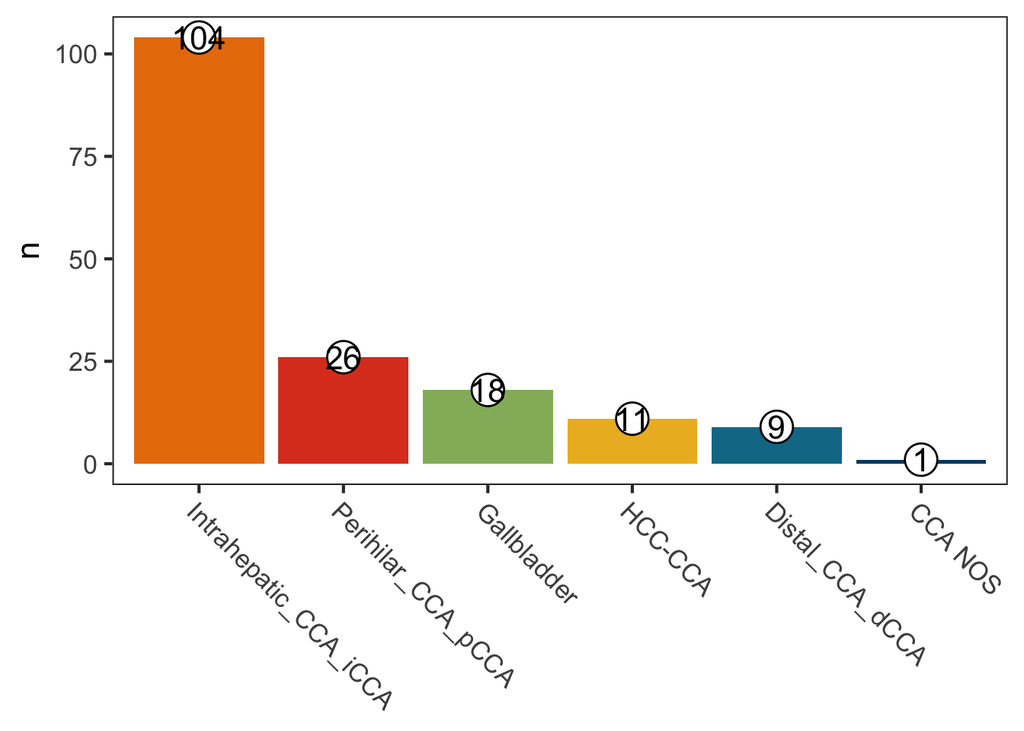

```r
ggplot(primary_location_tally, aes(x=reorder(variable, -n), y=n)) +
  geom_bar(stat='identity',aes(fill=variable)) +
  geom_point(size=7, color = 'white', shape=16) +
  geom_point(size=7,  shape=1) +
  geom_text(aes(label=n)) +
  scale_fill_manual(values = pnw_palette(name="Bay", n=length(unique(primary_location_tally$variable)) ), na.value = 'grey90') +
  guides(fill='none')+
  theme_bw(base_size=16) +
  theme(axis.text.x = element_text(hjust = -0, angle = -45),
        axis.title.x = element_blank(),
        panel.grid = element_blank()

  )
```

```r
all.samples %>% group_by(tissue_before_chemo) %>% tally()
```

```
## # A tibble: 2 × 2
##   tissue_before_chemo     n
##   <lgl>               <int>
## 1 FALSE                  64
## 2 TRUE                  105
```

```r
BTC_clinical.tumours %>% group_by(`Group ID(LCM/non-LCM)`) %>% tally()
```

```
## # A tibble: 2 × 2
##   `Group ID(LCM/non-LCM)`     n
##   <chr>                   <int>
## 1 LCM                       153
## 2 no LCM                     16
```

```r
BTC_clinical.tumours %>% group_by(`Sample Source(FFPE, FF)`) %>% tally()
```

```
## # A tibble: 2 × 2
##   `Sample Source(FFPE, FF)`     n
##   <chr>                     <int>
## 1 FF                          148
## 2 FFPE                         21
```

```r
BTC_clinical.tumours %>% group_by(rna) %>% tally()
```

```
## # A tibble: 2 × 2
##   rna       n
##   <lgl> <int>
## 1 FALSE    35
## 2 TRUE    134
```

```r
median(btc.coverage$V4[btc.coverage$V1 %in% sample.list$tumour])
```

```
## [1] 85
```

```r
median(btc.coverage$V4[btc.coverage$V1 %in% sample.list$normal])
```

```
## [1] 38
```

```r
cat(round(median(btc.rna.coverage$V3[btc.rna.coverage$V1 %in% sample.list$tumour])/1000000, 2), 'million transcripts')
```

```
## 84.21 million transcripts
```

```r
BTC_clinical.tumours %>% group_by(rna, `Sample Source(FFPE, FF)`) %>% tally()
```

```
## # A tibble: 4 × 3
## # Groups:   rna [2]
##   rna   `Sample Source(FFPE, FF)`     n
##   <lgl> <chr>                     <int>
## 1 FALSE FF                           32
## 2 FALSE FFPE                          3
## 3 TRUE  FF                          116
## 4 TRUE  FFPE                         18
```

## make table of tumors to be uploaded to EGA

```r
  new_samples_for_upload <- BTC_clinical.tumours %>% filter(previous == 'new') %>% dplyr::select(`Study ID`, Donor, Sample, Normal, rna) %>% arrange(desc(`Study ID`))

  patient.info <- all.clinic %>% dplyr::select(Study_ID, Age_at_first_histological_diagnosis, Sex_assigned_at_birth)
  new_samples_for_upload <- left_join(new_samples_for_upload, patient.info, by=c('Study ID'='Study_ID'))


  sample_types <- all.samples %>% dplyr::select(Study_ID, Sample_Progression, Site_of_tissue)
  new_samples_for_upload <- left_join(new_samples_for_upload, sample_types, by=c('Study ID'='Study_ID'))



  write.table(new_samples_for_upload,  file = file.path(basedir,"/results/new_samples_for_upload.txt"), row.names = FALSE, quote = FALSE, sep = "\t")
```